# Seguimiento a Embarques

Manual de Usuario

2025-01-30

Presione →

## Instrucciones para el uso de la presentacion

Utilice las flechas ←/→ para avanzar en la presentacion

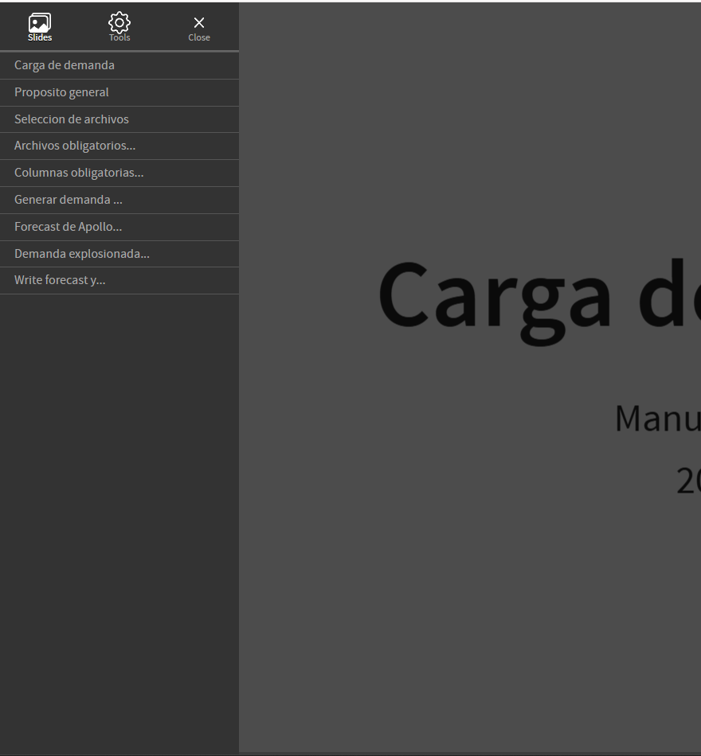

[figure not shown]

Haga click en el menu en la esquina inferior izquierda para desplegar el indice de la ayuda y saltar a una seccion en particular

## Proposito general

El objetivo principal es generar el reporte OOR que contiene la demanda del EDI y el estatus de cada orden/modelo, muestra el historial de las ordenes:

- En que work orders se han trabajado los productos
- Cuando se enviaron a ELP
- Cuando se enviaron al Cliente

### Seleccion de archivos

Ejecute el codigo de la primera celda para generar el menu de seleccion de archivos

[figure not shown]

[figure not shown]

Seleccione en esta seccion el folder de salidas

Los repotes y archivos auxiliares se crearan en esta carpeta

Las fechas pueden modificarse para modificar la manera en que se integran los datos, el detalle se explicara mas adelante

Utilice los botones para seleccionar los archivos de trabajo del proceso.

- Archivos obligatorios:
  - Tracker
- Opcionales:
  - ELP Master
  - Shipment transactions
  - InventoryStageBackup

## Explorar Outlook

Esta seccion es opcional

El proceso buscara en su correo electronico en Outlook archivos adjuntos con el nombre ‘Korrus’ y los descargara en el folder “attachments” que se creara en caso de que no exista

La fecha marcada como “Fecha mail” en el menu de selecciones indica la fecha a partir de la cual se explorara el mail. Puede seleccionar una fecha anterior si considera que algun archivo no se ha integrado, los datos no se duplicaran si se explora la misma fecha dos veces

Al final del proceso se generaran dos archivos de trabajo:

- Korrus_list: Indica el nombre del archivo integrado y la fecha en que se recibio el mail con este archivo adjunto. La columna Status muestra “e” en caso de que el archivo no se integrara debido a un error. Colocando “r” en el campo Status se puede integrar de nuevo un archivo en caso de que se hayan realizado correcciones en el mismo
- Korrus_data.xlsx: Muestra los datos integrados de los diferentes archivos, la primera columna “origin_file”, muestra el nombre del archivo de donde provienen los datos

## Outlook Classic

El proceso de exploracion de outlook funciona solo con la version de escritorio, por lo tanto es necesario desactivar la opcion “Try the new outlook”

[figure not shown]

[figure not shown]

Si esta opcion de outlook no esta disponible o si es necesario integrar archivos de Korrus de otra fuente del Email, coloque archivos directamente en el folder “attachments” y ejecute el proceso “Explorar Outlook”

## Flujo de datos

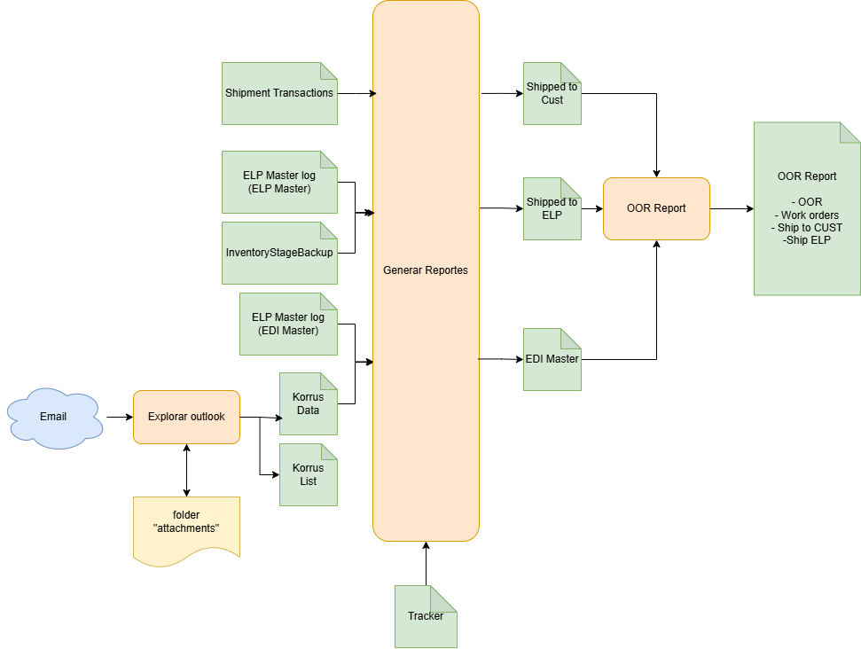

Es necesario proveer cuatro fuentes de informacion:

```
El EDI, ya sea del proceso de exploracion del email o del formato ELP Master log o ambos
```

[figure not shown]

```
Los embarques a ELP que proviene de ELP Master log (Hoja: ELP Master) o del reporte InventoryStageBackup o de ambos
```

[figure not shown]

```
El Shipment Transactions para determinar los embarques al cliente

El reporte Tracker con el detalle de las work orders
```

[figure not shown]

El proceso concentra los datos de las diferentes fuentes en los archivos intermedios:

- Shipped to Cust.xlsx
- Shipped to ELP.xlsx
- EDI Master.xlsx

Se integran los datos y luego se eliminan los duplicados tomando en cuenta la llave de cada archivo, por ejemplo para el EDI Master se eliminan los duplicados por: ‘PurchaseOrder’,‘PODate’,‘LineNumber’,‘ProductServiceID’,‘AssignedDropZone’

De este modo pueden agregarse datos manualmente al archivo EDI Master y el proceso los tomara en cuenta sin duplicarlos

### Reporte OOR

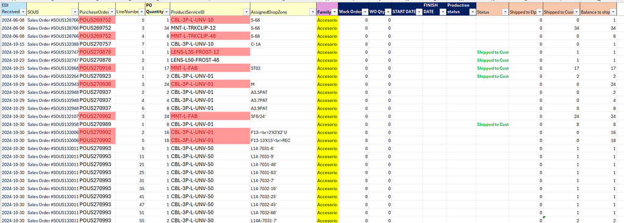

El resultado final del proceso es el archivo OOR Report.xlsx

```
Se encuentra ordenado por Family/PurchaseOrder/ProductServiceId/Fecha y el color agrupa las lineas de una misma PO/Producto
```

[figure not shown]

```
La columna Status muestra el estado de la orden completa, es decir, dice "Shipped to ELP" solo si toda la orden se embarco a ELP y "Shipped to Cust" si toda la orden se embarco al cliente
```

[figure not shown]

```
Las columnas Work Order, Shipped to Elp, Shipped to Cust contienen hyperlinks que dirigen a los datos que originaron la sumatoria en las otras pestañas del workbook
```

[figure not shown]